# ML Course project

### Introduction

Using devices such as Jawbone Up, Nike FuelBand, and Fitbit it is now possible to collect a large amount of data about personal activity relatively inexpensively. These type of devices are part of the quantified self movement - a group of enthusiasts who take measurements about themselves regularly to improve their health, to find patterns in their behavior, or because they are tech geeks. One thing that people regularly do is quantify how much of a particular activity they do, but they rarely quantify how well they do it. In this project, your goal will be to use data from accelerometers on the belt, forearm, arm, and dumbell of 6 participants. They were asked to perform barbell lifts correctly and incorrectly in 5 different ways. More information is available from the website here: [http://web.archive.org/web/20161224072740/http:/groupware.les.inf.puc-rio.br/har] (see the section on the Weight Lifting Exercise Dataset).

#### Data Source

The training data for this project are available here:

https://d396qusza40orc.cloudfront.net/predmachlearn/pml-training.csv

The test data are available here:

https://d396qusza40orc.cloudfront.net/predmachlearn/pml-testing.csv

The data for this project come from this source: http://web.archive.org/web/20161224072740/http:/groupware.les.inf.puc-rio.br/har. If you use the document you create for this class for any purpose please cite them as they have been very generous in allowing their data to be used for this kind of assignment.

### 1.Pre-precoessing data

Remove all the columns that have all NAs and exclude all the irrlevant columns

```r
subs = names(test[,colSums(is.na(test)) == 0])[8:59]

train = train[,c(subs,"classe")]
test = test[,c(subs, "problem_id")]
valid = test

dim(train); dim(test)
```

```
[1] 19622    53
```

```
[1] 20 53
```

### 2. Splitting Data

Splitting data into 80% for training set and 20% for testing set

```r
set.seed(1)

inTrain = createDataPartition(train$classe, p=0.8, list=FALSE)
training = train[inTrain,]
testing = train[-inTrain,]

dim(training)
```

```
[1] 15699    53
```

### 3.Dropping some undesirable variables

```r
require(caret)

Pred.info = nearZeroVar(training, saveMetrics = TRUE)

training = training[,!Pred.info$nzv]

dim(training)
```

```
[1] 15699    53
```

### 4. Exploratory analysis

```r
require(ggplot2)

table(training$classe)
```

```
   A    B    C    D    E
4464 3038 2738 2573 2886
```

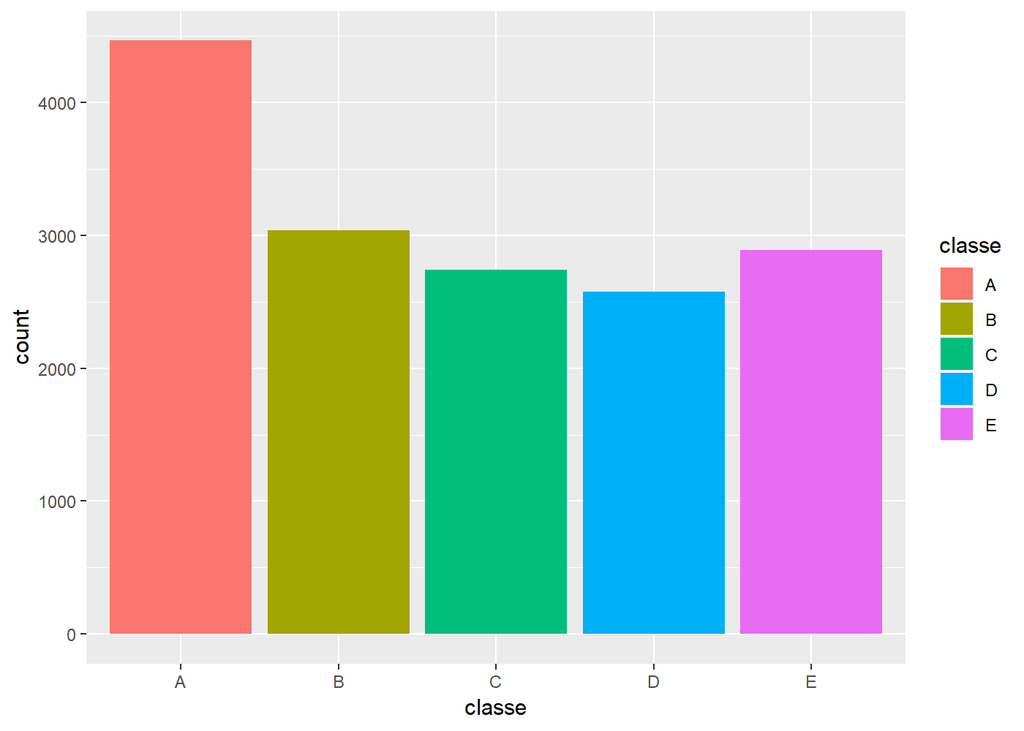

```r
ggplot(training, aes(classe))+
    geom_bar(aes(fill = classe), position = "dodge")
```

### 5.Building Decision tree as basic model

```r
Model.0 = train(classe ~., method = "rpart", data = training)
print(Model.0$finalModel)
```

```
n= 15699

node), split, n, loss, yval, (yprob)
      * denotes terminal node

 1) root 15699 11235 A (0.28 0.19 0.17 0.16 0.18)
   2) roll_belt< 130.5 14369  9915 A (0.31 0.21 0.19 0.18 0.11)
     4) pitch_forearm< -33.95 1258     9 A (0.99 0.0072 0 0 0) *
     5) pitch_forearm>=-33.95 13111  9906 A (0.24 0.23 0.21 0.2 0.12)
      10) magnet_dumbbell_y< 439.5 11079  7934 A (0.28 0.18 0.24 0.19 0.11)
        20) roll_forearm< 122.5 6869  4054 A (0.41 0.18 0.18 0.17 0.06) *
        21) roll_forearm>=122.5 4210  2827 C (0.078 0.18 0.33 0.23 0.18) *
      11) magnet_dumbbell_y>=439.5 2032   984 B (0.03 0.52 0.044 0.22 0.19) *
   3) roll_belt>=130.5 1330    10 E (0.0075 0 0 0 0.99) *
```

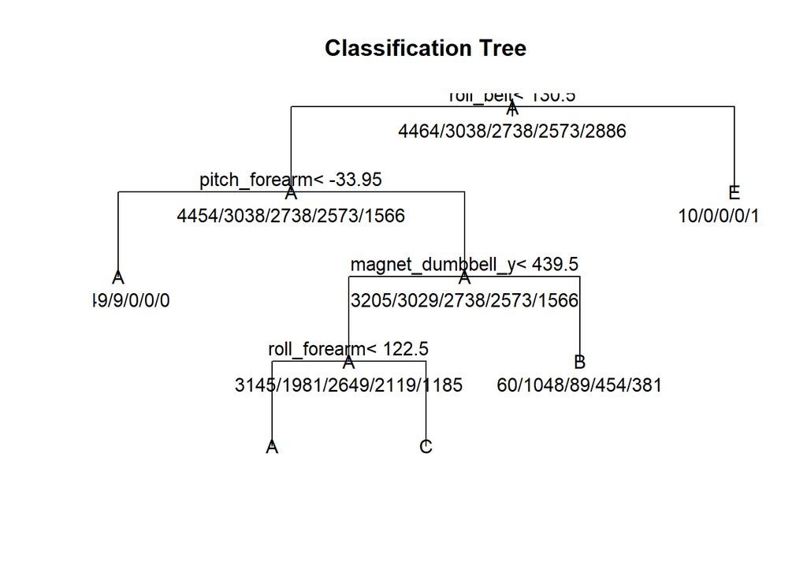

```r
{plot(Model.0$finalModel, uniform = TRUE, main = "Classification Tree")
text(Model.0$finalModel, use.n = TRUE, all = TRUE, cex = 1)}
```

```r
pred.0 = predict(Model.0, newdata = testing)
table(pred.0)
```

```
pred.0
   A    B    C    D    E
2059  497 1052    0  315
```

```r
confusionMatrix(pred.0, testing$classe)$overall[1]
```

```
 Accuracy
0.4855978
```

The result of the simple decision tree shows very low accuracy. Moreover, decision tree does not predict class “D”

### 6.Biuld random forest

```r
Model1 = randomForest(classe ~ ., data = training)


pred1 = predict(Model1, newdata = testing)

table(pred1)
```

```
pred1
   A    B    C    D    E
1117  761  686  638  721
```

```r
confusionMatrix(pred1, testing$classe)$overall[1]
```

```
Accuracy
0.994647
```

The result shows a very high accuracy

### 7.Predict clasee with test data

```r
predClasse = predict(Model1, newdata = test)
predClasse
```

```
 1  2  3  4  5  6  7  8  9 10 11 12 13 14 15 16 17 18 19 20
 B  A  B  A  A  E  D  B  A  A  B  C  B  A  E  E  A  B  B  B
Levels: A B C D E
```

```r
answers <- as.vector(predClasse)

pml_write_files = function(x) {
    n = length(x)
    for (i in 1:n) {
        filename = paste0("prediction_", i, ".txt")
        write.table(x[i], file = filename, quote = FALSE, row.names = FALSE,
            col.names = FALSE)
    }
}
```

pml_write_files(answers)